# Evaluation Task Machine Learning for Turbulent Fluid Dynamics

```python
import numpy as np
import matplotlib.pyplot as plt
```

### Generating the Symmetric Matrices

To generate symmetric matrix from any general matrix M, we can do any one of the following

M_symm = (M+M.T)/2

M_symm = M*M.T

Using rules of matrix transpose, it can be shown that these two matrices are symmetric for any matrix M

```python
N = 10
A = np.random.rand(N,N)
A_Symm = (A + A.T)/2
A_Symm*=2
A_Symm-=1
print(A_Symm)
```

```
[[ 0.51362694  0.02375238 -0.57354865 -0.52947567 -0.56655558 -0.00100043
   0.21929146 -0.1587675   0.64460971 -0.22849717]
 [ 0.02375238  0.85687269  0.86637343 -0.6393855   0.50356679 -0.56710161
  -0.28202469  0.25638067  0.74370076  0.39420788]
 [-0.57354865  0.86637343 -0.20362728  0.41619781 -0.0674289   0.73669033
  -0.6785701   0.14691901  0.02618289  0.10853407]
 [-0.52947567 -0.6393855   0.41619781 -0.61600671 -0.12818749  0.04868083
  -0.57794609  0.33673342 -0.06714558  0.05619415]
 [-0.56655558  0.50356679 -0.0674289  -0.12818749 -0.58481996  0.15938876
  -0.3046379   0.39828063  0.80487648 -0.69462498]
 [-0.00100043 -0.56710161  0.73669033  0.04868083  0.15938876  0.99068038
   0.14516898 -0.08241913  0.26028619  0.51602895]
 [ 0.21929146 -0.28202469 -0.6785701  -0.57794609 -0.3046379   0.14516898
  -0.61249417 -0.1417148   0.81758531 -0.17464582]
 [-0.1587675   0.25638067  0.14691901  0.33673342  0.39828063 -0.08241913
  -0.1417148   0.89679732 -0.2961392  -0.0670925 ]
 [ 0.64460971  0.74370076  0.02618289 -0.06714558  0.80487648  0.26028619
   0.81758531 -0.2961392   0.6153814  -0.23107845]
 [-0.22849717  0.39420788  0.10853407  0.05619415 -0.69462498  0.51602895
  -0.17464582 -0.0670925  -0.23107845  0.14642859]]
```

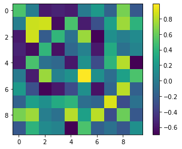

```python
plt.imshow(A_Symm)
plt.colorbar()
plt.savefig("Original Matrix")
plt.show()
```

### Eigenvectors and Eigenvalues

There are two standard methods to compute the eigenvectors and eigenvalues, one for any general matrices, the second one is specifically for real symmetric matrices Since, this is a symmetric matrix, the eigenvalues are all always real the set of eigenvectors are orthogonal and hence represent the "dimensions" or "degrees of freedom" in which the data exists

```python
W, V = np.linalg.eig(A_Symm)
print("The eigenvalues are \n")
print(W)
print("The eigenvectors are \n")
print(V)
```

```
The eigenvalues are

[ 2.17746757  2.02819928  1.5618529  -2.14835398  0.9576927   0.54601796
 -1.73757565 -0.10570437 -0.88034648 -0.39641073]
The eigenvectors are

[[-0.40590252 -0.32845758  0.04840936  0.28806855 -0.08100624  0.54761805
  -0.00276859 -0.54917049 -0.16996785 -0.07140934]
 [-0.40134277  0.62980716 -0.09682022 -0.05486476 -0.37679816  0.08432039
  -0.49936468 -0.00916899  0.03708314  0.17312288]
 [ 0.1448123   0.45279265  0.24728691  0.30873667 -0.1055309  -0.08945966
   0.45153661 -0.40563666  0.47253523 -0.0817515 ]
 [ 0.29327398  0.07109931  0.01274624  0.2316118   0.16632393 -0.10547144
  -0.55627518 -0.16478143 -0.02845117 -0.69205233]
 [-0.16921227  0.26857131 -0.02574508  0.56672736  0.38956908 -0.27932628
   0.10563638  0.06342577 -0.53947778  0.20344179]
 [ 0.16620644  0.04174608  0.83356909 -0.14882385  0.22997872  0.14790007
  -0.27297487 -0.05236924 -0.08134798  0.30823168]
 [-0.26138429 -0.24660095  0.09901254  0.49551921  0.1267833   0.06046358
  -0.19828155  0.46213957  0.58032281  0.0782974 ]
 [ 0.16403861  0.35528614 -0.27823386 -0.10408752  0.53109801  0.66223906
   0.09112728  0.14084193  0.09758868 -0.01802605]
 [-0.62152251  0.11240367  0.28014482 -0.33982411  0.25601971 -0.12356776
   0.23392453  0.14087289  0.00256769 -0.50172314]
 [ 0.17149017  0.10878474  0.25645697  0.2232972  -0.49428862  0.34131257
   0.22200248  0.49660216 -0.31887032 -0.29108861]]
```

```python
## Get the dimensions of the matrices

print("A_Symm ", A_Symm.shape)
print("Eigenvectors ", V.shape)
print("Eigenvalues ", W.shape)
```

```
A_Symm  (10, 10)
Eigenvectors  (10, 10)
Eigenvalues  (10,)
```

```python
w, v = np.linalg.eigh(A_Symm)
print("The eigenvalues are \n")
print(w)
print("The eigenvectors are \n")
print(v)
```

```
The eigenvalues are

[-2.14835398 -1.73757565 -0.88034648 -0.39641073 -0.10570437  0.54601796
  0.9576927   1.5618529   2.02819928  2.17746757]
The eigenvectors are

[[ 0.28806855  0.00276859  0.16996785  0.07140934  0.54917049 -0.54761805
   0.08100624  0.04840936  0.32845758 -0.40590252]
 [-0.05486476  0.49936468 -0.03708314 -0.17312288  0.00916899 -0.08432039
   0.37679816 -0.09682022 -0.62980716 -0.40134277]
 [ 0.30873667 -0.45153661 -0.47253523  0.0817515   0.40563666  0.08945966
   0.1055309   0.24728691 -0.45279265  0.1448123 ]
 [ 0.2316118   0.55627518  0.02845117  0.69205233  0.16478143  0.10547144
  -0.16632393  0.01274624 -0.07109931  0.29327398]
 [ 0.56672736 -0.10563638  0.53947778 -0.20344179 -0.06342577  0.27932628
  -0.38956908 -0.02574508 -0.26857131 -0.16921227]
 [-0.14882385  0.27297487  0.08134798 -0.30823168  0.05236924 -0.14790007
  -0.22997872  0.83356909 -0.04174608  0.16620644]
 [ 0.49551921  0.19828155 -0.58032281 -0.0782974  -0.46213957 -0.06046358
  -0.1267833   0.09901254  0.24660095 -0.26138429]
 [-0.10408752 -0.09112728 -0.09758868  0.01802605 -0.14084193 -0.66223906
  -0.53109801 -0.27823386 -0.35528614  0.16403861]
 [-0.33982411 -0.23392453 -0.00256769  0.50172314 -0.14087289  0.12356776
  -0.25601971  0.28014482 -0.11240367 -0.62152251]
 [ 0.2232972  -0.22200248  0.31887032  0.29108861 -0.49660216 -0.34131257
   0.49428862  0.25645697 -0.10878474  0.17149017]]
```